# Visualizing the Catholic Lectionary

Exploratory Data Analysis

Stefan Avey <avey.stefan@gmail.com>

31 May 2020

# Background

## What’s a Lectionary?

A [lectionary](https://en.wikipedia.org/wiki/Lectionary), according to Wikipedia, is a listing of scripture readings for Christian or Judaic worship on a given day. The Roman Catholic Lectionary will contain a list of readings for a specific day that are on a 3-year cycle. Here is an example:

Thirtieth Sunday in Ordinary Time  
Lectionary: 149  
**Reading 1**: Jer 31:7-9  
**Psalm**: Ps 126:1-2, 2-3, 4-5, 6  
**Reading 2**: Heb 5:1-6  
**Gospel**: Mk 10:46-52

As a Catholic, I’ve often wondered how much of the Bible is included in the lectionary. Fortunately, Felix Just, S.J., Ph.D. compiled a [website with statistics](http://catholic-resources.org/Lectionary/Statistics.htm) on many aspects of the lectionary which help to answer this question.

His analysis shows that a Catholic who attends Mass on Sundays and Feasts (but not weekdays) would hear **~ 4%** of the Old Testament (excluding Psalms) and **~ 41%** of the New Testament. Wow - this was a shock to me! I bet if you ask around you’ll hear that many Catholics think the lectionary includes the whole Bible. To be fair, these numbers do get a bit higher if you include the complete lectionary (with weekdays). The total coverage of the Old Testament is **~14%** (again excluding Psalms) and for the New Testament it is **~72%**.

## Ok Cool, But Isn’t the Lectionary a Book?

[figure not shown]

Yes, the lectionary is traditionally a book. But it’s the 21<sup>st</sup> century and luckily someone else has transcribed this into an electronic listing so I didn’t have to do it. The data necessary includes the [Sunday Lectionary](http://catholic-resources.org/Lectionary/Index-Sundays.htm) and a pair of reference guides that tell us how many chapters/verses are in each book of the Bible ([Old Testament Reference](http://catholic-resources.org/Bible/OT-Statistics-Compared.htm), [New Testament Reference](http://catholic-resources.org/Bible/NT-Statistics-Greek.htm)). I could have played with web scraping but there were only a few tables so I just copied the tables in Felix’s website into Excel files ([link to data files](https://github.com/stefanavey/stefanavey.github.io/tree/master/_posts/catholic/plotBible)).

```r
########################
## Read in references ##
########################
testaments <- c("OT", "NT")
abbrev <- map(testaments, ~read_excel(abbrevFile, sheet = .x))
names(abbrev) <- testaments

## Old Testament
OTsections <- c("Torah", "Historical", "Wisdom", "MajorProphets", "MinorProphets")
OTref <- map_df(OTsections, function(OTsection) {
    read_excel(OTRefFile, sheet = OTsection, na = ".") %>%
        mutate(Section = OTsection)
}) %>%
    rename(Book = `Book Name`) %>%
    gather(matches("[0-9]+"), key = "Chapter", value = "Verses") %>%
    filter(!is.na(Verses)) %>%
    select(Section, Book, Chapter, Verses) %>%
    mutate(Book = factor(Book,            # Order books in factor levels
                         levels = abbrev$OT$Name),
           Abbrv = abbrev$OT$Abbreviation[match(Book, abbrev$OT$Name)],
           Chapter = as.numeric(Chapter)) %>%
    arrange(Book) %>%
    mutate(Abbrv = factor(Abbrv, levels = unique(Abbrv)))

## Munge so that reference contains 1 row for every verse in the order they
## appear in the Old Testament with a `Pos` column to denote the position of the
## verse.
OTref2Pos <- OTref %>%
    arrange(Book, Chapter) %>%
    mutate(Verse = map(Verses, function(x) 1:x)) %>%
    unnest() %>%
    mutate(Chapter_Verse = paste(Chapter, Verse, sep = ':')) %>%
    mutate(Pos = 1:n()) %>%
    mutate(Testament = "Old")

## New Testament
NTsections <- c("Gospels", "NT")
NTref <- map_df(NTsections, function(NTsection) {
    read_excel(NTRefFile, sheet = NTsection, na = ".") %>%
        mutate(Section = NTsection) %>%
        mutate_at(vars(matches("[0-9]+")),
                  funs(as.integer(str_replace(., fixed("*"), ""))))
}) %>%
    rename(Abbrv = `Book  Name`) %>%
    gather(matches("[0-9]+"), key = "Chapter", value = "Verses") %>%
    filter(!is.na(Verses)) %>%
    select(Section, Abbrv, Chapter, Verses) %>%
    mutate(Abbrv = factor(Abbrv,
                         levels = abbrev$NT$Abbreviation),
           Book = abbrev$NT$Name[match(Abbrv, abbrev$NT$Abbreviation)],
           Chapter = as.numeric(Chapter)) %>%
    arrange(Abbrv) %>%
    mutate(Book = factor(Book, levels = unique(Book)))

## Munge so that reference contains 1 row for every verse in the order they
## appear in the New Testament with a `Pos` column to denote the position of the
## verse.
NTref2Pos <- NTref %>%
    arrange(Book, Chapter) %>%
    mutate(Verse = map(Verses, function(x) 1:x)) %>%
    unnest() %>%
    mutate(Chapter_Verse = paste(Chapter, Verse, sep = ':')) %>%
    mutate(Pos = 1:n()) %>%
    mutate(Testament = "New")

ref2Pos <- bind_rows(OTref2Pos, NTref2Pos) %>%
    mutate(Pos = 1:n())

## Get named list of sections with abbreviations in each one
sections <- ref2Pos %>%
    select(Section, Abbrv) %>%
    distinct() %>%
    group_by(Section) %>%
    mutate(Abbrv = list(Abbrv)) %>%
    distinct() %>%
    deframe()

## Get book IDs from API Bible
request <- paste0(
    "curl --request GET \\",
    "--url https://api.scripture.api.bible/v1/bibles/",
    bible_id, "/books \\",
    "--header 'api-key: ", API_BIBLE_KEY, "\'")
tmp <- system(request, intern = TRUE)
apibible_books <- fromJSON(tmp)$data %>%
                              mutate(Name = str_remove(name, fixed(" (Greek)"))) %>%
                              mutate(Name = str_replace(Name,
                                                        "Song of Solomon",
                                                        "Song of Songs")) %>%
                              mutate(Name = str_replace(Name,
                                                        "Wisdom of Solomon",
                                                        "Wisdom"))
api_book_map <- deframe(select(apibible_books, Name, id))
```

# Data Overview

## Reference Data

There is a lot of data transformation necessary but in the end, we have a data frame with 35,524 rows which contains 1 row for every verse in the Catholic Bible. This will be used as the reference to compare the lectionary to. Below I show part of the table containing the first and last 6 verses.

```r
ref2Pos %>%
    select(Testament, Section, Book, Chapter, Verse, Pos) %>%
    head() %>%
    knitr::kable()
```

| Testament | Section | Book | Chapter | Verse | Pos |
| --- | --- | --- | --- | --- | --- |
| Old | Torah | Genesis | 1 | 1 | 1 |
| Old | Torah | Genesis | 1 | 2 | 2 |
| Old | Torah | Genesis | 1 | 3 | 3 |
| Old | Torah | Genesis | 1 | 4 | 4 |
| Old | Torah | Genesis | 1 | 5 | 5 |
| Old | Torah | Genesis | 1 | 6 | 6 |

```r
ref2Pos %>%
    select(Testament, Section, Book, Chapter, Verse, Pos) %>%
    tail() %>%
    knitr::kable()
```

| Testament | Section | Book | Chapter | Verse | Pos |
| --- | --- | --- | --- | --- | --- |
| New | NT | Revelation | 22 | 16 | 35519 |
| New | NT | Revelation | 22 | 17 | 35520 |
| New | NT | Revelation | 22 | 18 | 35521 |
| New | NT | Revelation | 22 | 19 | 35522 |
| New | NT | Revelation | 22 | 20 | 35523 |
| New | NT | Revelation | 22 | 21 | 35524 |

## Lectionary Data

```r
###################################################
## Read in the Lectionary for Sundays and Feasts ##
###################################################
LectSundays <- map(readings, ~read_excel(LectSundaysFile, sheet = .x))
names(LectSundays) <- readings

SunLect <- bind_rows(LectSundays) %>%
    tbl_df() %>%
    separate(LectNum_Year, c("LectNum", "Year"), sep = '-') %>%
    mutate(YearA = grepl("A", Year),
           YearB = grepl("B", Year),
           YearC = grepl("C", Year)) %>%
    mutate(LectNum = as.numeric(LectNum))

#########################################
## Read in the Lectionary for Weekdays ##
#########################################
LectWeekdays <- map(readings, ~read_excel(LectWeekdaysFile, sheet = .x))
names(LectWeekdays) <- readings

wdLect <- bind_rows(LectWeekdays) %>%
    tbl_df() %>%
    mutate(Year1 = str_detect(Year, "1"),
           Year2 = str_detect(Year, "2"))
```

Below are some entries in the lectionary including the **Reading** as well as the **Year** in the 3-year cycle (ABC means read in years A, B, and C). For this analysis, I’ll ignore the **Year** and just consider the coverage over the whole 3-year cycle.

```r
SunLect %>%
    select(Reading, LectNum, Year, Day) %>%
    head() %>%
    kable()
```

| Reading | LectNum | Year | Day |
| --- | --- | --- | --- |
| Gen 1:1-2:2 or 1:1, 26-31a | 41 | ABC | Easter Vigil (1st Reading) |
| Gen 2:7-9; 3:1-7 | 22 | A | 1st Sunday of Lent |
| Gen 2:18-24 | 140 | B | 27th Sunday in Ordinary Time |
| Gen 3:9-15 | 89 | B | 10th Sunday in Ordinary Time |
| Gen 9:8-15 | 23 | B | 1st Sunday of Lent |
| Gen 11:1-9 | 62 | ABC | Pentecost Sunday: Vigil Mass (Option 1) |

```r
wdLect %>%
    select(Reading, LectNum, Year, Day) %>%
    head() %>%
    kable()
```

| Reading | LectNum | Year | Day |
| --- | --- | --- | --- |
| Gen 1:1-19 | 329 | 1 | Ord. Time, Week 5, Mon |
| Gen 1:20-2:4a | 330 | 1 | Ord. Time, Week 5, Tues |
| Gen 2:4b-9, 15-17 | 331 | 1 | Ord. Time, Week 5, Wed |
| Gen 2:18-25 | 332 | 1 | Ord. Time, Week 5, Thurs |
| Gen 3:1-8 | 333 | 1 | Ord. Time, Week 5, Fri |
| Gen 3:9-24 | 334 | 1 | Ord. Time, Week 5, Sat |

# Methodology

## Parsing Verses

The crucial part is matching the **Reading** to the reference. This seems straightforward but can be very tricky in some cases. I wrote a basic parser ([see code](https://github.com/stefanavey/stefanavey.github.io/blob/master/_posts/catholic/plotBible/helperFunctions.R)) to handle the most common cases. It ignores some aspects such as the “or” option as in the first row of the table above. Usually an “or” option gives a longer form followed by a shorter form (subset of the first option) so I’ll only consider the longer forms.

Each set of continuous verses gets stored in a new data frame by the parser. For example, *Gen 1:1-2:2 or 1:1, 26-31a* will get parsed to:

```r
ParseFull(SunLect$Reading[1])
```

| start | end | Abbrv |
| --- | --- | --- |
| 1:1 | 2:2 | Gen |

and *Gen 2:7-9; 3:1-7* will get parsed to:

```r
ParseFull(SunLect$Reading[2])
```

| start | end | Abbrv |
| --- | --- | --- |
| 2:7 | 2:9 | Gen |
| 3:1 | 3:7 | Gen |

Then, once each reading from the lectionary is parsed, it gets matched back to the reference.

```r
## Apply parser on the full Sunday Lectionary
res <- SunLect %>%
    mutate(Pos = map(Reading, function(x) {
        ## cat(x, sep = '\n') # debugging
        ParseFull(x) %>%
        left_join(ref2Pos, by = c(start = "Chapter_Verse", Abbrv = "Abbrv")) %>%
        left_join(ref2Pos, by = c(end = "Chapter_Verse", Abbrv = "Abbrv")) %>%
        rowwise() %>%
            do(data.frame(Pos = if (any(is.na(.))) {
                                    NA
                                } else {
                                    .$Pos.x:.$Pos.y
                                }
                          )) %>%
            pull(Pos)}))

## Combine the results with the reference
sun_data <- res %>%
    unnest(Pos) %>%
    left_join(ref2Pos, by = "Pos")


## Apply parser on the full Weekday Lectionary
res <- wdLect %>%
    mutate(Pos = map(Reading, function(x) {
        ## cat(x, sep = '\n') # debugging
        ParseFull(x) %>%
        left_join(ref2Pos, by = c(start = "Chapter_Verse", Abbrv = "Abbrv")) %>%
        left_join(ref2Pos, by = c(end = "Chapter_Verse", Abbrv = "Abbrv")) %>%
        rowwise() %>%
            do(data.frame(Pos = if (any(is.na(.))) {
                                    NA
                                } else {
                                    .$Pos.x:.$Pos.y
                                }
                          )) %>%
            pull(Pos)}))

## Combine the results with the reference
wd_data <- res %>%
    unnest(Pos) %>%
    left_join(ref2Pos, by = "Pos")
```

```r
full_data <- bind_rows(sun_data, wd_data)
```

### Parsing Errors

There are some parsing errors that need to be resolved. The table below shows all the readings from the lectionary which are *not* properly matched to the reference and need some manual intervention.

```r
## Debugging
wd_data %>%
    filter(is.na(Pos)) %>%
    select(Reading) %>%
    kable()
```

| Reading |
| --- |
| Exod 15:8-9, 10+12, 17 |
| Num 13:1-2, 25-14:1, 26a-29a, 34-35 |
| Deut 32:3-4ab, 7, 8, 9+12 |
| 2 Sam 18:9-10, 14b, 24-25a, 30-19:3 |
| Esth C:12, 14-16, 23-25 |
| Esth C:12, 14-16, 23-25 |
| Esth C:12, 14-16, 23-25 |
| Eccl/Qoh 1:2-11 |
| Eccl/Qoh 3:1-11 |
| Eccl/Qoh 11:9-12:8 |
| Cant 2:8-14 |
| Ps 1:1-2, 3, 4+6 |
| Ps 1:1-2, 3, 4+6 |
| Ps 1:1-2, 3, 4+6 |
| Ps 1:1-2, 3, 4+6 |
| Ps 1:1-2, 3, 4+6 |
| Ps 1:1-2, 3, 4+6 |
| Ps 1:1-2, 3, 4+6 |
| Ps 1:1-2, 3, 4+6 |
| Ps 1:1-2, 3, 4+6 |
| Ps 2:7bc-8, 10-12a |
| Ps 8:2ab+5, 6-7, 8-9 |
| Ps 8:2ab+5, 6-7, 8-9 |
| Ps 9:2-3, 4+6, 16+19 |
| Ps 9:2-3, 4+6, 16+19 |
| Ps 9:2-3, 6+16, 8-9 |
| Ps 11:4, 5+7 |
| Ps 16:1-2a+5, 7-8, 11 |
| Ps 16:1-2a+5, 7-8, 9-10, 11 |
| Ps 16:1-2a+5, 7-8, 9-10, 11 |

[output cut: 124 more lines]

So each reading is parsed into multiple segments and then mapped onto the position variable (**Pos**) from the Reference. The result for one reading looks like this:

```r
sun_data %>%
    select(Reading, Section, Book, Chapter, Verse, Pos) %>%
    filter(Reading == "Isa 63:16b-17, 19b; 64:2-7") %>%
    kable()
```

| Reading | Section | Book | Chapter | Verse | Pos |
| --- | --- | --- | --- | --- | --- |
| Isa 63:16b-17, 19b; 64:2-7 | MajorProphets | Isaiah | 63 | 16 | 22923 |
| Isa 63:16b-17, 19b; 64:2-7 | MajorProphets | Isaiah | 63 | 17 | 22924 |
| Isa 63:16b-17, 19b; 64:2-7 | MajorProphets | Isaiah | 63 | 19 | 22926 |
| Isa 63:16b-17, 19b; 64:2-7 | MajorProphets | Isaiah | 64 | 2 | 22928 |
| Isa 63:16b-17, 19b; 64:2-7 | MajorProphets | Isaiah | 64 | 3 | 22929 |
| Isa 63:16b-17, 19b; 64:2-7 | MajorProphets | Isaiah | 64 | 4 | 22930 |
| Isa 63:16b-17, 19b; 64:2-7 | MajorProphets | Isaiah | 64 | 5 | 22931 |
| Isa 63:16b-17, 19b; 64:2-7 | MajorProphets | Isaiah | 64 | 6 | 22932 |
| Isa 63:16b-17, 19b; 64:2-7 | MajorProphets | Isaiah | 64 | 7 | 22933 |

# Analysis Questions

## Are shorter books better covered?

It appears that there is no consistent relationship between book length (number of verses) and the percent read in the lectionary.

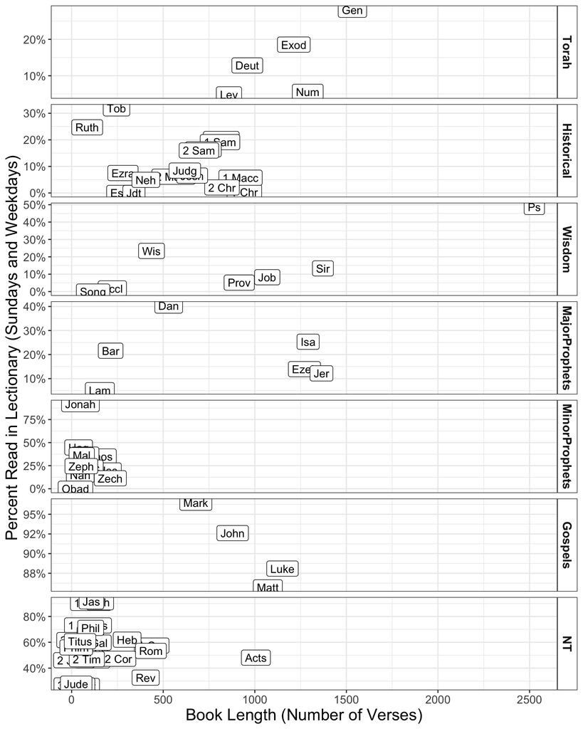

```r
verse_per_book <- ref2Pos %>%
    group_by(Book, Abbrv, Testament, Section) %>%
    summarize(N_Verses = n())

verse_read <- full_data %>%
    filter(!is.na(Pos)) %>%
    group_by(Book, Abbrv, Testament, Section) %>%
    summarize(N_Read = length(unique(Pos)))

unread_df <- left_join(verse_per_book, verse_read,
                    by = c("Book", "Abbrv", "Testament", "Section")) %>%
    mutate(N_Read = ifelse(is.na(N_Read), 0, N_Read)) %>%
    mutate(N_Unread = N_Verses - N_Read) %>%
    mutate(Perc_Read = N_Read / N_Verses) %>%
    mutate(Section = factor(Section, levels = names(sections)))

ggplot(data = unread_df, aes(x = N_Verses, y = Perc_Read, label = Abbrv)) +
    geom_point() +
    geom_label() +
    xlab("Book Length (Number of Verses)") +
    ylab("Percent Read in Lectionary (Sundays and Weekdays)") +
    scale_y_continuous(labels = function(x) percent(x, accuracy = 1)) +
    facet_grid(Section ~ ., scales = "free_y") +
    getBaseTheme() +
    theme(strip.text = element_text(size = 12, face='bold'))
```

## What books are not read or rarely read?

### Metric: Verses

The table below shows the data and you can sort by either quantity unread (**N_Unread**) or percent unread (**Perc_Unread**).

```r
unread_df %>%
    select(Testament, Section, Abbrv, N_Verses, N_Read, N_Unread, Perc_Read) %>%
    DT::datatable()
```

|  | Book | Testament | Section | Abbrv | N_Verses | N_Read | N_Unread | Perc_Read |
| --- | --- | --- | --- | --- | --- | --- | --- | --- |
| 1 | 1 Chronicles | Old | Historical | 1 Chr | 943 | 3 | 940 | 0.0031813361611877 |
| 2 | 1 Corinthians | New | NT | 1 Cor | 437 | 251 | 186 | 0.574370709382151 |
| 3 | 1 John | New | NT | 1 John | 105 | 95 | 10 | 0.904761904761905 |
| 4 | 1 Kings | Old | Historical | 1 Kgs | 817 | 166 | 651 | 0.203182374541004 |
| 5 | 1 Maccabees | Old | Historical | 1 Macc | 922 | 53 | 869 | 0.0574837310195228 |
| 6 | 1 Peter | New | NT | 1 Pet | 105 | 58 | 47 | 0.552380952380952 |
| 7 | 1 Samuel | Old | Historical | 1 Sam | 810 | 155 | 655 | 0.191358024691358 |
| 8 | 1 Thessalonians | New | NT | 1 Thess | 89 | 65 | 24 | 0.730337078651685 |
| 9 | 1 Timothy | New | NT | 1 Tim | 113 | 52 | 61 | 0.460176991150442 |
| 10 | 2 Chronicles | Old | Historical | 2 Chr | 821 | 17 | 804 | 0.0207064555420219 |

[output cut: 63 more lines]

```r
not_covered <- unread_df %>%
    filter(N_Read == 0) %>%
    arrange(Section) %>%
    pull(Abbrv)
```

### Metric: Chapters Covered

Another way to consider how much is read in each book is to think about the concept of coverage. Two books could have the same percent of verses read but one could be all at the beginning of the book and the other spread throughout all chapters of the book. This can be seen a bit visually in the “bookshelf” visualization but here we quantify this by calculating the coverage at the chapter level and comparing percent of verses read with percent of chapters with at least some level of coverage.

```r
min_coverage <- 0.10
min_coverage_perc <- percent(min_coverage, accuracy = 1)
coverage <- full_data %>%
    filter(!is.na(Pos)) %>%
    full_join(ref2Pos, by = c("Section", "Book", "Chapter", "Verses", "Abbrv", "Verse",
                              "Chapter_Verse", "Pos", "Testament")) %>%
    select(Reading, Section, Abbrv, Chapter, Verse, Pos) %>%
    mutate(Coverage = as.numeric(!is.na(Reading))) %>%
    arrange(Pos) %>%
    filter(!duplicated(Pos)) %>%
    group_by(Section, Abbrv, Chapter) %>%
    summarize(N_Verses = max(Pos) - min(Pos) + 1,
              N_Read = sum(Coverage),
              Perc_Read = N_Read / N_Verses,
              Chap_Covered = Perc_Read > min_coverage) %>%
    group_by(Section, Abbrv) %>%
    summarize(N_Verses = sum(N_Verses),
              N_Read = sum(N_Read),
              Perc_Read = N_Read / N_Verses,
              Perc_Chapters_Covered = mean(Chap_Covered))

coverage %>%
    mutate(Perc_Chapters_Covered = round(Perc_Chapters_Covered, 2)) %>%
    mutate(Perc_Read = round(Perc_Read, 2)) %>%
    select(Section, Abbrv, N_Verses, N_Read, Perc_Read, Perc_Chapters_Covered) %>%
    DT::datatable()
```

|  | Section | Abbrv | N_Verses | N_Read | Perc_Read | Perc_Chapters_Covered |
| --- | --- | --- | --- | --- | --- | --- |
| 1 | Gospels | John | 879 | 814 | 0.93 | 1 |
| 2 | Gospels | Luke | 1151 | 1014 | 0.88 | 1 |
| 3 | Gospels | Mark | 678 | 654 | 0.96 | 1 |
| 4 | Gospels | Matt | 1071 | 918 | 0.86 | 1 |
| 5 | Historical | 1 Chr | 943 | 3 | 0 | 0 |
| 6 | Historical | 1 Kgs | 817 | 166 | 0.2 | 0.45 |
| 7 | Historical | 1 Macc | 922 | 53 | 0.06 | 0.25 |
| 8 | Historical | 1 Sam | 810 | 155 | 0.19 | 0.42 |
| 9 | Historical | 2 Chr | 821 | 17 | 0.02 | 0.06 |
| 10 | Historical | 2 Kgs | 719 | 118 | 0.16 | 0.36 |

[output cut: 63 more lines]

The table above shows how the number of chapters covered (by reading at least 10% of verses in the chapter). The plot below shows that there is some interesting variation between this metric and just looking at the total percent read in each book. For example, comparing Col and 1 John we see that they have similar percent of chapters covered (75% vs 80%) even though 1 John has 90% of verses read while Col only has 66% read. They are books with similar length. This indicates that while there is less read in Col, the coverage is similar in terms of hitting 80% of chapters with at least 10% coverage.

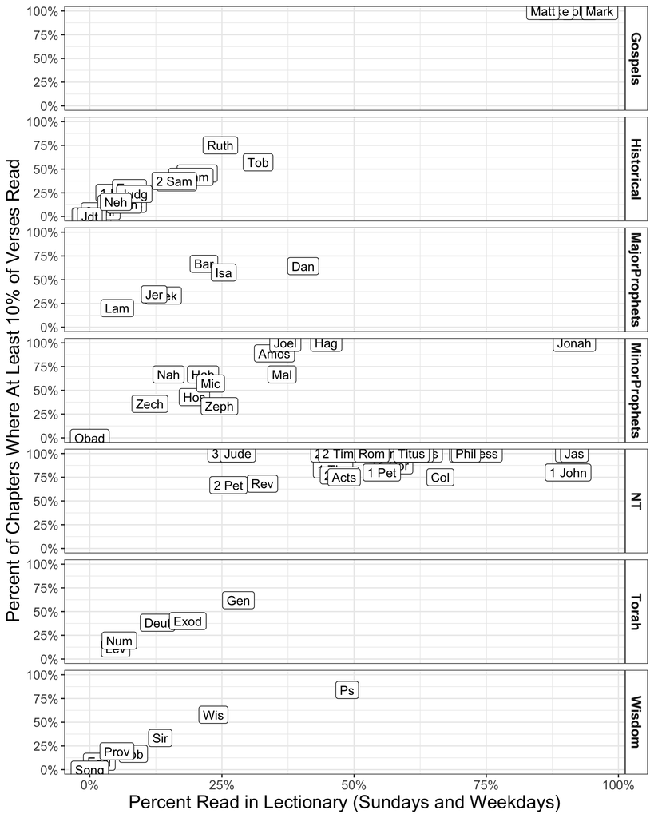

```r
ggplot(data = coverage, aes(x = Perc_Read, y = Perc_Chapters_Covered, label = Abbrv)) +
    geom_point() +
    geom_label() +
    xlab("Percent Read in Lectionary (Sundays and Weekdays)") +
    ylab(paste("Percent of Chapters Where At Least", min_coverage_perc, "of Verses Read")) +
    scale_x_continuous(labels = function(x) percent(x, accuracy = 1)) +
    scale_y_continuous(labels = function(x) percent(x, accuracy = 1)) +
    facet_grid(Section ~ .) +
    getBaseTheme() +
    theme(strip.text = element_text(size = 12, face='bold'))
```

```r
## Algorithm assumes that the lectionary data frame has valid Reading entry
stopifnot(all(!is.na(full_data$Reading)))

##' calculate_gap_penalty
##'
##' Calculate the sum of gap penalties from a vector of coverage
##'
##' @param x numeric vector of coverage with 0 indicating not covered and 1 indicating covered
##'
##' @param A numeric penalty for opening a gap
##' @param B numeric penalty for extending a gap. The length of gap is raised to this power
##' @details gaps are extracted from x by considering 1 or more values of 0 as
##'     gaps in coverage. Defaults to small penalty for opening a gap since some
##'     verses here and then can be skipped and larger penalty for extending a
##'     gap.
##' @return a single numeric value giving the sum of gap penalties normalized by
##'     length of input vector.
##'
##' @examples
##' set.seed(1234)
##' len <- 20
##' x_half <- rep(c(1, 0), each = len/2)
##' x_quart <- rep(rep(c(1, 0), each = len/4), 2)
##' x_random <- sample(x_half)
##' calculate_gap_penalty(x_random)
##' calculate_gap_penalty(x_half)
##' calculate_gap_penalty(x_quart)
##'
##' len <- 40
##' x_random <- rep(x_random, 2)
##' x_half <- rep(c(1, 0), each = len/2)
##' x_quart <- rep(rep(c(1, 0), each = len/4), 2)
##' calculate_gap_penalty(x_random)
##' calculate_gap_penalty(x_half)
##' calculate_gap_penalty(x_quart)
calculate_gap_penalty <- function(x, A = 0, B = 2) {
    ## Check that x is an atomic vector of type numeric and that it only contains 0 or 1.
    stopifnot(is.atomic(x) && is.numeric(x))
    stopifnot(all(x == 0 | x == 1))
    ## Handle edge cases of all 0's by considering it 1 gap of length(x)
    if (all(x == 0)) {
        return(0)
    }
    ## Get vector L of lengths of all gaps (one entry per gap)
    L <- c()
    in_gap <- FALSE
    gap_length <- 0
    for(ii in seq_along(x)) {
        if (x[ii] == 0 && in_gap) {
            gap_length <- gap_length + 1
        } else if (x[ii] == 0 && !in_gap) {
            in_gap <- TRUE
            gap_length <- gap_length + 1
        } else if (x[ii] == 1 && in_gap) {
            L <- c(L, gap_length)
            in_gap <- FALSE
            gap_length <- 0
        }
        ## Handle case where x ends in 0's
        if (ii == length(x) && in_gap) {
            L <- c(L, gap_length)
        }
    }
    return(sum(A + (L / length(x))^B))
}

gap_data <- full_data %>%
    filter(!is.na(Pos)) %>%
    full_join(ref2Pos, by = c("Section", "Book", "Chapter", "Verses", "Abbrv", "Verse",
                              "Chapter_Verse", "Pos", "Testament")) %>%
    select(Reading, Section, Abbrv, Chapter, Verse, Pos) %>%
    mutate(Coverage = as.numeric(!is.na(Reading))) %>%
    arrange(Pos) %>%
    filter(!duplicated(Pos)) %>%
    group_by(Section, Abbrv) %>%
    summarize(N_Verses = max(Pos) - min(Pos) + 1,
              N_Read = sum(Coverage),
              Gap_Penalty = calculate_gap_penalty(Coverage)) %>%
    mutate(Perc_Read = N_Read / N_Verses) %>%
    ungroup() %>%
    arrange(-Gap_Penalty)

gap_data %>%
    mutate(Gap_Penalty = round(Gap_Penalty, 2)) %>%
    mutate(Perc_Read = round(Perc_Read, 2)) %>%
    select(Section, Abbrv, N_Verses, N_Read, Perc_Read, Gap_Penalty) %>%
    DT::datatable()

plot(gap_data$Perc_Read, gap_data$Gap_Penalty)

## Compare 1 Tim vs. 2 John
c1 <- gap_data %>%
    filter(Abbrv == "1 Tim") %>%
    pull(Coverage)
c2 <- gap_data %>%
    filter(Abbrv == "2 John") %>%
    pull(Coverage)

## NOTE: This doesn't really work well and can't compare sequences of different sizes. Tried affine gap penalty as well as other variations like square of length but couldn't get desired outcome on toy examples. Decided to go with something more statistical.
```

```r
## IDEAS:
## - Calculate AUC of data or smoothed data?
## - Think of null hypothesis and perform statistical test
len <- 20
x_half <- rep(c(1, 0), each = len/2)
x_quart <- rep(rep(c(1, 0), each = len/4), 2)
x_random <- sample(x_half)

plot_data <- tibble(x = 1:len, x_random, x_quart, x_half)

ggplot(data = plot_data, aes(x = x, y = x_random)) +
    geom_point() +
    geom_line()

ggplot(data = plot_data, aes(x = x, y = x_half)) +
    geom_point() +
    geom_line()

ggplot(data = plot_data, aes(x = x, y = x_quart)) +
    geom_point() +
    geom_line()
```

## What verses are most frequently read in Lectionary?

We want to see what verses are read most often at Mass.

```r
verse_read <- full_data %>%
    filter(!is.na(Pos)) %>%
    group_by(Book, Abbrv, Testament, Section, Chapter, Verse) %>%
    summarize(Count = n()) %>%
    ungroup() %>%
    arrange(-Count) %>%
    mutate(verse_id = paste(api_book_map[Book], Chapter, Verse, sep = "."))

verse_read %>%
    select(Testament, Section, Abbrv, Chapter, Verse, Count) %>%
    DT::datatable()
```

|  | Testament | Section | Abbrv | Chapter | Verse | Count |
| --- | --- | --- | --- | --- | --- | --- |
| 1 | Old | Wisdom | Ps | 98 | 3 | 28 |
| 2 | Old | Wisdom | Ps | 23 | 3 | 21 |
| 3 | Old | Wisdom | Ps | 146 | 9 | 17 |
| 4 | Old | Wisdom | Ps | 98 | 1 | 16 |
| 5 | Old | Wisdom | Ps | 40 | 8 | 15 |
| 6 | Old | Wisdom | Ps | 103 | 1 | 15 |
| 7 | Old | Wisdom | Ps | 103 | 2 | 15 |
| 8 | Old | Wisdom | Ps | 95 | 7 | 14 |
| 9 | Old | Wisdom | Ps | 98 | 2 | 14 |
| 10 | Old | Wisdom | Ps | 98 | 4 | 14 |

[output cut: 10331 more lines]

We can see that the most highly read verses are from the Psalms, which is not surprising as the book of Psalms is read at nearly every mass during the responsorial.

The most read verse is:

```r
## Get an ID that API can use to look up the verse.
cat(lookup_verse(verse_id = verse_read[["verse_id"]][1]))
```

3He has remembered his loving kindness and his faithfulness toward the house of Israel.

All the ends of the earth have seen the salvation of our God.

# Visualizations

## “Bookshelf” Visualization

The inspiration behind this visualization is picturing the whole Bible as a bookshelf. There is one row for each major section (e.g., Torah, Minor Prophets, Gospels) and each section is made up of multiple books. In the visualization, lines are used to indicate coverage of a particular verse in the lectionary.

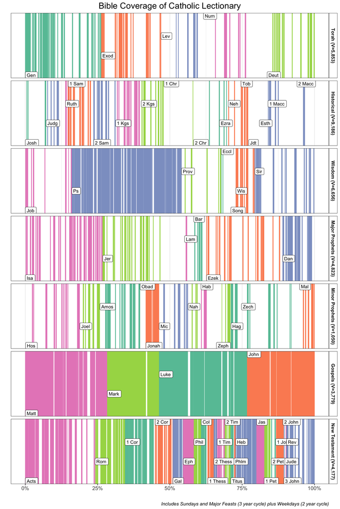

```r
## Get all section lengths
sectPos <- map_int(names(sections), function(sect) {
    abbrvs <- sections[[sect]]
    lastAbbrv <- abbrvs[length(abbrvs)]
    maxPos <- ref2Pos %>%
        filter(Abbrv == lastAbbrv) %>%
        pull(Pos) %>%
        max()
    return(maxPos)
})
names(sectPos) <- names(sections)
sectPos2 <- c(0, sectPos[-length(sectPos)])
names(sectPos2) <- names(sectPos)
sectLength <- sectPos - sectPos2

## Tweak Section Labels for Plot
sectLabels <- names(sections) %>%
    paste0(., " (V=", comma(sectLength[.]), ")") %>%
    str_replace("Prophets", " Prophets") %>%
    str_replace("NT", "New Testament") %>%
    setNames(names(sections))

## Generate plotting data
plot_data <- full_data %>%
    filter(!is.na(Pos)) %>%
    select(Section, Abbrv, Chapter, Verse, Pos) %>%
    mutate(Pos = (Pos - sectPos2[Section]) / sectLength[Section]) %>%
    mutate(SectionLabel = factor(sectLabels[Section],
                                 levels = sectLabels)) %>%
    mutate(Label = paste0(Abbrv, " ", Chapter, ":", Verse)) %>%
    distinct()      # ignore how many times something appeared (read 2 or 3 times)
book_dat <- ref2Pos %>%
    mutate(Abbrv = factor(Abbrv, levels = unique(Abbrv))) %>%
    mutate(Pos = (Pos - sectPos2[Section]) / sectLength[Section]) %>%
    mutate(SectionLabel = factor(sectLabels[Section],
                                 levels = sectLabels)) %>%
    group_by(SectionLabel, Abbrv) %>%
    summarize(Pos = min(Pos)) %>%
    ungroup() %>%
    group_by(SectionLabel) %>%
    mutate(y = rep(c(0, 0.33, 0.66, 1), length.out = n())) %>%
    ungroup()

cols <- rep(brewer.pal(n = 5, name = "Set2"), length.out = length(unique(plot_data$Abbrv)))
names(cols) <- unique(plot_data$Abbrv)

## Create the plot
gg <- ggplot(plot_data, x = 0, y = 1) +
    geom_vline(aes(xintercept = Pos, color = Abbrv), show.legend = FALSE) +
    geom_label(data = book_dat, aes(x = Pos, y = y, label = Abbrv),
               hjust = 0, size = 3.5) +
    scale_color_manual(values = cols) +
    scale_x_continuous(labels = percent) +
    scale_y_continuous(labels = NULL, breaks = NULL) +
    xlab("") +
    ylab("") +
    ggtitle("Bible Coverage of Catholic Lectionary") +
    labs(caption = paste("Includes Sundays and Major Feasts (3 year cycle)",
                         "plus Weekdays (2 year cycle)")) +
    facet_grid(SectionLabel ~ ., scales = "fixed") +
    getBaseTheme() +
    theme(strip.text = element_text(size = 10, face = "bold"))
plot(gg)
```

```r
GetCoverage <- function(abbrv) {
    tot <- ref2Pos %>%
        filter(Abbrv == abbrv) %>%
        select(Chapter_Verse) %>%
        distinct() %>%
        nrow()
    cov <- plot_data %>%
        filter(Abbrv == abbrv) %>%
        select(Pos) %>%
        distinct() %>%
        nrow()
    return(cov/tot)
}
```

While most of the Old Testament is sparsely covered, the Psalms (abbreviated *Ps*) are one of the most covered books at 49% coverage. One of the drawbacks of this visualization is that each row contains a different number of verses so that the visual sense of “fullness” can be deceiving.

## Barplot

Now, instead of visualizing the covered verses in order, consider just the question of how much of each book in the Bible is covered by the Catholic Lectionary?

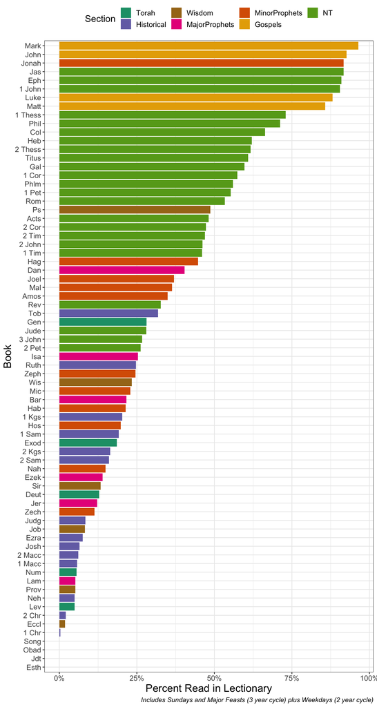

```r
verse_per_book <- ref2Pos %>%
    group_by(Book, Abbrv, Testament, Section) %>%
    summarize(N_Verses = n()) %>%
    ungroup()

verse_read <- full_data %>%
    filter(!is.na(Pos)) %>%
    group_by(Book, Abbrv, Testament, Section) %>%
    summarize(N_Read = length(unique(Pos))) %>%
    ungroup()

plot_data <- left_join(verse_per_book, verse_read,
                    by = c("Book", "Abbrv", "Testament", "Section")) %>%
    mutate(N_Read = ifelse(is.na(N_Read), 0, N_Read)) %>%
    mutate(N_Unread = N_Verses - N_Read) %>%
    mutate(Perc_Read = N_Read / N_Verses) %>%
    mutate(Section = factor(Section, levels = names(sections))) %>%
    arrange(Perc_Read) %>%
    mutate(Abbrv = factor(Abbrv, levels = unique(Abbrv)))

cols <- brewer.pal(n = 7, name = "Dark2")[c(1, 3, 7, 4, 2, 6, 5)]
names(cols) <- levels(plot_data$Section)

ggplot(data = plot_data, aes(x = Abbrv, y = Perc_Read, fill = Section)) +
    geom_col() +
    coord_flip() +
    xlab("Book") +
    ylab("Percent Read in Lectionary") +
    scale_y_continuous(labels = function(x) percent(x, accuracy = 1)) +
    scale_fill_manual(values = cols) +
    labs(caption = paste("Includes Sundays and Major Feasts (3 year cycle)",
                         "plus Weekdays (2 year cycle)")) +
    getBaseTheme() +
    theme(strip.text = element_text(size = 12, face='bold'),
          legend.pos = "top")
```

# Acknowledgments

Huge kudos to Felix Just, S.J., Ph.D. for compiling these resources:

- [Biblical Book Names & Abbreviations](http://catholic-resources.org/Bible/Abbreviations-Abreviaciones.htm)
- [Old Testament Reference](http://catholic-resources.org/Bible/OT-Statistics-Compared.htm)
- [New Testament Reference](http://catholic-resources.org/Bible/NT-Statistics-Greek.htm)
- [Scripture Index of Lectionary Readings Used for Weekday Masses](http://catholic-resources.org/Lectionary/Index-Weekdays.htm)
- [Scripture Index of Lectionary Readings Used for Sundays and Major Feasts](http://catholic-resources.org/Lectionary/Index-Sundays.htm)

# Appendix

## Source Code

R Source code is available online [here](https://github.com/stefanavey/lectionary-analysis/blob/master/src/lectionary_eda.Rmd)

## R Session Info

**R version 3.6.2 (2019-12-12)**

**Platform:** x86_64-apple-darwin19.2.0 (64-bit)

**locale:** en_US.UTF-8||en_US.UTF-8||en_US.UTF-8||C||en_US.UTF-8||en_US.UTF-8

**attached base packages:** *stats*, *graphics*, *grDevices*, *utils*, *datasets*, *methods* and *base*

**other attached packages:** *aveytoolkit(v.0.1.1.0000)*, *rvest(v.0.3.5)*, *xml2(v.1.2.2)*, *jsonlite(v.1.6.1)*, *RColorBrewer(v.1.1-2)*, *DT(v.0.12)*, *knitr(v.1.28)*, *scales(v.1.1.0)*, *forcats(v.0.5.0)*, *stringr(v.1.4.0)*, *dplyr(v.0.8.4)*, *purrr(v.0.3.3)*, *readr(v.1.3.1)*, *tidyr(v.1.0.2)*, *tibble(v.2.1.3)*, *ggplot2(v.3.2.1)*, *tidyverse(v.1.3.0)*, *readxl(v.1.3.1)*, *pander(v.0.6.3)*, *devtools(v.2.2.2)* and *usethis(v.1.5.1)*

**loaded via a namespace (and not attached):** *nlme(v.3.1-142)*, *fs(v.1.3.1)*, *lubridate(v.1.7.4)*, *httr(v.1.4.1)*, *rprojroot(v.1.3-2)*, *tools(v.3.6.2)*, *backports(v.1.1.5)*, *R6(v.2.4.1)*, *DBI(v.1.1.0)*, *lazyeval(v.0.2.2)*, *colorspace(v.1.4-1)*, *withr(v.2.1.2)*, *tidyselect(v.1.0.0)*, *prettyunits(v.1.1.1)*, *processx(v.3.4.2)*, *compiler(v.3.6.2)*, *cli(v.2.0.2)*, *desc(v.1.2.0)*, *labeling(v.0.3)*, *callr(v.3.4.2)*, *digest(v.0.6.25)*, *rmarkdown(v.2.1)*, *pkgconfig(v.2.0.3)*, *htmltools(v.0.4.0)*, *sessioninfo(v.1.1.1)*, *fastmap(v.1.0.1)*, *dbplyr(v.1.4.2)*, *highr(v.0.8)*, *htmlwidgets(v.1.5.1)*, *rlang(v.0.4.5)*, *rstudioapi(v.0.11)*, *shiny(v.1.4.0)*, *generics(v.0.0.2)*, *farver(v.2.0.3)*, *crosstalk(v.1.0.0)*, *magrittr(v.1.5)*, *Rcpp(v.1.0.3)*, *munsell(v.0.5.0)*, *fansi(v.0.4.1)*, *lifecycle(v.0.1.0)*, *stringi(v.1.4.6)*, *yaml(v.2.2.1)*, *pkgbuild(v.1.0.6)*, *plyr(v.1.8.5)*, *grid(v.3.6.2)*, *promises(v.1.1.0)*, *crayon(v.1.3.4)*, *lattice(v.0.20-38)*, *haven(v.2.2.0)*, *hms(v.0.5.3)*, *ps(v.1.3.2)*, *pillar(v.1.4.3)*, *reshape2(v.1.4.3)*, *codetools(v.0.2-16)*, *pkgload(v.1.0.2)*, *reprex(v.0.3.0)*, *glue(v.1.3.1)*, *evaluate(v.0.14)*, *remotes(v.2.1.1)*, *modelr(v.0.1.6)*, *httpuv(v.1.5.2)*, *vctrs(v.0.2.3)*, *testthat(v.2.3.2)*, *cellranger(v.1.1.0)*, *gtable(v.0.3.0)*, *assertthat(v.0.2.1)*, *xfun(v.0.12)*, *mime(v.0.9)*, *xtable(v.1.8-4)*, *broom(v.0.5.5)*, *later(v.1.0.0)*, *memoise(v.1.1.0)* and *ellipsis(v.0.3.0)*